# 机器学习之曲线分离

李誉辉

2020/12/14

# 1 引言

在现实环境中，我们有许多时间序列数据，比如超市零售数据，可能同时包括成千上万种商品的销量历史数据。 不同商品销量随时间会有不同的变化。如果需要对销量进行预测，首先就应该根据趋势，对商品进行分类。 然后对同一类的商品建立相同的模型，当然模型的参数略微有些不同。

似乎很少见到根据曲线趋势进行分类的例子，如何评价曲线的趋势？这是一个问题。 我们首先应该想到，相关系数可以评价2个曲线之间的相关程度。 同一类曲线之间，应该具有较高的相关系数。因此，我们可以先计算曲线之间的相关系数， 构成相关矩阵，然后转换为数据框，再进行聚类分析。考虑到上千条曲线，产生的矩阵维度非常高， 因此在聚类分析之前，还应该进行PCA降维。

相关系数具有正负性，在计算相关系数之前，最好先将上升和下降趋势的曲线分离， 然后分别计算相关系数和聚类分析。毕竟对于上升和下降的时间序列，模型差异会非常大。 如何分离上升和下降趋势的曲线？最简单的方法，就是建立一阶线性回归模型， 然后用`coef(model)[2]`提取拟合曲线的斜率，如果斜率$>0$，则为上升趋势，$<0$则为下降趋势。

考虑到不同商品的单价差异巨大，在一张图上绘制所有曲线，不便于观察，首先就需要使用`scale`进行放缩。

# 2 需要的包

```r
rm(list = ls()); gc() # 清空内存
setwd("D:/R/working_documents1") # 工作目录
library(dplyr)
library(magrittr)
library(purrr)
library(tibble)
library(tidyr)
library(ggplot2)
library(readr)

library(data.table) # big data process
library(lubridate) # date data process
library(echarts4r)

library(psych) # PCA
library(ggdendro) #
library(dendextend)
library(ape)

library(patchwork)
library(modelr)
```

```
##          used (Mb) gc trigger (Mb) max used (Mb)
## Ncells 402511 21.5     839351 44.9   621360 33.2
## Vcells 739612  5.7    8388608 64.0  1599744 12.3
```

# 3 编造数据

为了方便演示，这里使用编造数据，因为真实的数据异常情况太多，每一步都需要筛选等预处理。

第一组曲线：

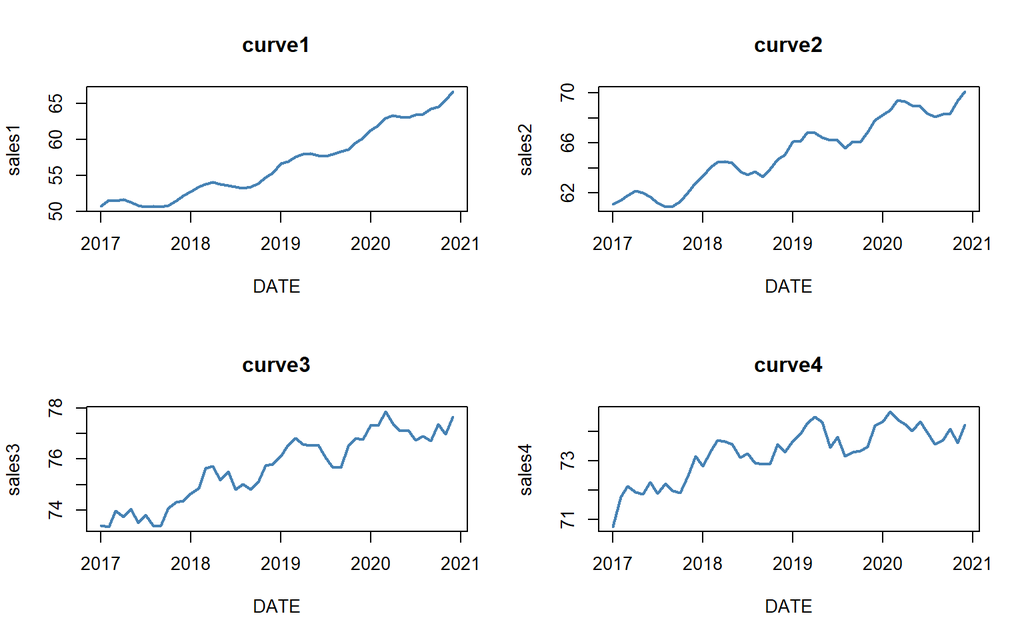

```r
curves_DT <-
  data.table(DATE = seq(from = as.Date("2017-01-01"),
                        to = as.Date("2020-12-31"),
                        by = "month"))
curves_DT[, x := 1:.N]

# 第1条曲线
curves_DT[, sales1 := sin(pi/6*x) + 0.005*x^2 + 0.1*x + 50 # 周期为12个月
          ][, sales1 := sales1 + runif(length(sales1))/100*sales1] # 增加随机扰动
# 第2条曲线
curves_DT[, sales2 := sin(pi/6*x) + 0.2*x + 60
          ][, sales2 := sales2 + runif(length(sales2))/100*sales2] # 增加随机扰动
# 第3条曲线
curves_DT[, sales3 := sin(pi/6*x)/2 + sqrt(x+5) + 70
          ][, sales3 := sales3 + runif(length(sales3))/100*sales3] # 增加随机扰动
# 第4条曲线
curves_DT[, sales4 := sin(pi/6*x)/2 + 0.5*log(x^2) + 70
          ][, sales4 := sales4 + runif(length(sales4))/100*sales4] # 增加随机扰动

# 画图
par(mfrow = c(2, 2))
curves_DT[, plot(DATE, sales1, type = "l", col = "steelblue", lwd = 2,
     main = "curve1")]
curves_DT[, plot(DATE, sales2, type = "l", col = "steelblue", lwd = 2,
     main = "curve2")]
curves_DT[, plot(DATE, sales3, type = "l", col = "steelblue", lwd = 2,
     main = "curve3")]
curves_DT[, plot(DATE, sales4, type = "l", col = "steelblue", lwd = 2,
     main = "curve4")]
```

第二组曲线：

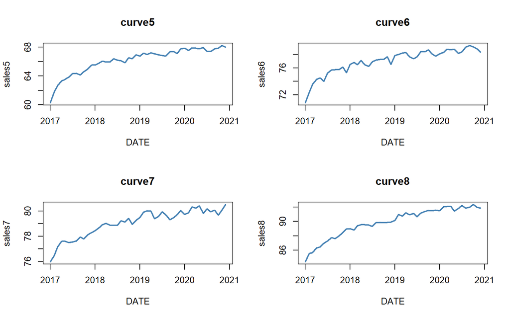

```r
# 第5条曲线
curves_DT[, sales5 := sin(pi/6*x)/4 + 2*log(x) + 60
          ][, sales5 := sales5 + runif(length(sales5))/100*sales5] # 增加随机扰动
# 第6条曲线
curves_DT[, sales6 := sqrt(abs(sin(pi/6*x))) + 2*log(x) + 70
          ][, sales6 := sales6 + runif(length(sales6))/100*sales6] # 增加随机扰动
# 第7条曲线
curves_DT[, sales7 := sin(pi/6*x)/4 + 5*sqrt(log(x+2)) + 70
          ][, sales7 := sales7 + runif(length(sales7))/100*sales7] # 增加随机扰动
# 第8条曲线
curves_DT[, sales8 := sin(pi/6*x)/6 + 3*log(x+3) + 80
          ][, sales8 := sales8 + runif(length(sales8))/100*sales8] # 增加随机扰动


# 画图
par(mfrow = c(2, 2))
curves_DT[, plot(DATE, sales5, type = "l", col = "steelblue", lwd = 2,
     main = "curve5")]
curves_DT[, plot(DATE, sales6, type = "l", col = "steelblue", lwd = 2,
     main = "curve6")]
curves_DT[, plot(DATE, sales7, type = "l", col = "steelblue", lwd = 2,
     main = "curve7")]
curves_DT[, plot(DATE, sales8, type = "l", col = "steelblue", lwd = 2,
     main = "curve8")]
```

第三组曲线：

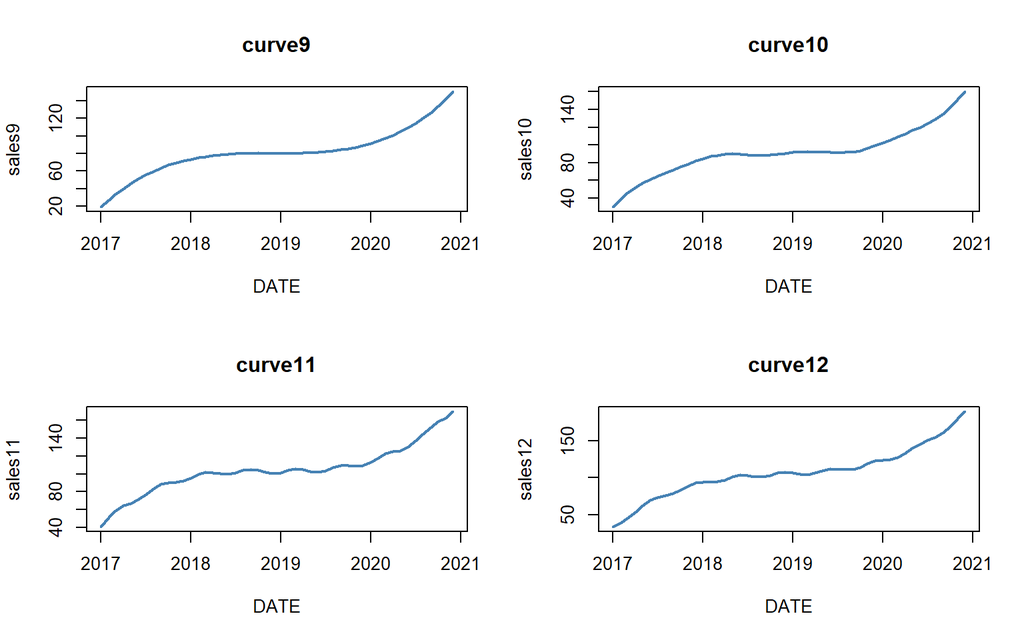

```r
# 第9条曲线
curves_DT[, sales9 := 0.005*(x-24)^3 + 80
          ][, sales9 := sales9 + runif(length(sales9))/100*sales9] # 增加随机扰动
# 第10条曲线
curves_DT[, sales10 := 0.005*(x-24)^3 + 2*sin(pi/6*x) + 90
          ][, sales10 := sales10 + runif(length(sales10))/100*sales10] # 增加随机扰动
# 第11条曲线
curves_DT[, sales11 := 0.005*(x-24)^3 + 5*sin(pi/6*x)^2 + 100
          ][, sales11 := sales11 + runif(length(sales11))/100*sales11] # 增加随机扰动
# 第12条曲线
curves_DT[, sales12 := 0.005*(x-24)^3 + 5*cos(pi/6*x)^2 + 0.5*x + 90
          ][, sales12 := sales12 + runif(length(sales12))/100*sales12] # 增加随机扰动


# 画图
par(mfrow = c(2, 2))
curves_DT[, plot(DATE, sales9, type = "l", col = "steelblue", lwd = 2,
     main = "curve9")]
curves_DT[, plot(DATE, sales10, type = "l", col = "steelblue", lwd = 2,
     main = "curve10")]
curves_DT[, plot(DATE, sales11, type = "l", col = "steelblue", lwd = 2,
     main = "curve11")]
curves_DT[, plot(DATE, sales12, type = "l", col = "steelblue", lwd = 2,
     main = "curve12")]
```

第四组曲线：

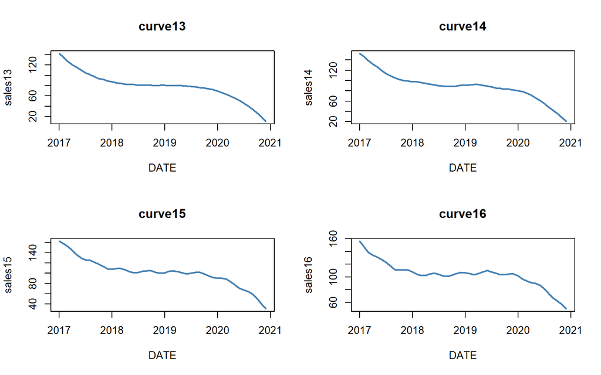

```r
# 第13条曲线
curves_DT[, sales13 := 0.005*(24-x)^3 + 80
          ][, sales13 := sales13 + runif(length(sales13))/100*sales13] # 增加随机扰动
# 第14条曲线
curves_DT[, sales14 := 0.005*(24-x)^3 + 2*sin(pi/6*x) + 90
          ][, sales14 := sales14 + runif(length(sales14))/100*sales14] # 增加随机扰动
# 第15条曲线
curves_DT[, sales15 := 0.005*(24-x)^3 + 5*sin(pi/6*x)^2 + 100
          ][, sales15 := sales15 + runif(length(sales15))/100*sales15] # 增加随机扰动
# 第16条曲线
curves_DT[, sales16 := 0.005*(24-x)^3 + 5*cos(pi/6*x)^2 + 0.5*x + 90
          ][, sales16 := sales16 + runif(length(sales16))/100*sales16] # 增加随机扰动

# 画图
par(mfrow = c(2, 2))
curves_DT[, plot(DATE, sales13, type = "l", col = "steelblue", lwd = 2,
     main = "curve13")]
curves_DT[, plot(DATE, sales14, type = "l", col = "steelblue", lwd = 2,
     main = "curve14")]
curves_DT[, plot(DATE, sales15, type = "l", col = "steelblue", lwd = 2,
     main = "curve15")]
curves_DT[, plot(DATE, sales16, type = "l", col = "steelblue", lwd = 2,
     main = "curve16")]
```

# 4 数据缩放

```r
curves_DT2 <-
  curves_DT %>%
  data.table::melt(id.vars = c("DATE", "x"),
                   variable.name = "curves",
                   value.name = "sales",
                   variable.factor = FALSE,
                   value.factor = FALSE) %>%
  .[, !"x"] %>% .[, sales_scale := scale(sales),
                  by = .(curves)]
curves_DT2 %>%
  as.data.frame() %>%
  group_by(curves) %>%
  e_charts(DATE) %>%
  e_line(sales) %>%
  e_title("产品销量走势") %>%
  e_theme("chalk") %>%
  e_tooltip(trigger = "axis")
```

[interactive chart not shown]

# 5 相关系数

```r
cor_df <- curves_DT[, !c("x", "DATE")] %>% as.data.frame()
rownames(cor_df) <- curves_DT$DATE
cor_df[1:6, 1:6]


cor_Mat <- cor_df %>%
  as.matrix() %>% # 转换为矩阵
  scale() %>% # 缩放
  cor(method = "pearson", use = "pairwise.complete.obs") # 计算相关性, use避免NA报错

dim(cor_Mat)
is.na(cor_Mat) %>% sum() %>% `/`(., 2014^2) # 计算NA的比例

cor_Mat[1:6, 1:6]
```

|  | sales1 | sales2 | sales3 | sales4 | sales5 | sales6 |
| --- | --- | --- | --- | --- | --- | --- |
| 2017-01-01 | 50.72433 | 61.08779 | 73.39644 | 70.75541 | 60.28108 | 70.79390 |
| 2017-02-01 | 51.52742 | 61.40071 | 73.35393 | 71.78010 | 61.82179 | 72.39565 |
| 2017-03-01 | 51.44043 | 61.80298 | 73.97636 | 72.14783 | 62.68341 | 73.55315 |
| 2017-04-01 | 51.61050 | 62.17086 | 73.75471 | 71.92745 | 63.31494 | 74.30628 |
| 2017-05-01 | 51.26054 | 62.01217 | 74.05407 | 71.86199 | 63.56160 | 74.53991 |
| 2017-06-01 | 50.79126 | 61.70596 | 73.51404 | 72.27622 | 63.86298 | 74.04613 |

```
## [1] 16 16
## [1] 0
##           sales1    sales2    sales3    sales4    sales5    sales6
## sales1 1.0000000 0.9733869 0.9223885 0.7822965 0.8153656 0.7953337
## sales2 0.9733869 1.0000000 0.9739815 0.8819202 0.8751024 0.8346459
## sales3 0.9223885 0.9739815 1.0000000 0.9146460 0.9022410 0.8598182
## sales4 0.7822965 0.8819202 0.9146460 1.0000000 0.9090027 0.8522166
## sales5 0.8153656 0.8751024 0.9022410 0.9090027 1.0000000 0.9647682
## sales6 0.7953337 0.8346459 0.8598182 0.8522166 0.9647682 1.0000000
```

# 6 聚类

```r
cor_Mat2 <- ifelse(is.na(cor_Mat), 0.1, cor_Mat)
cor_Mat2 <- ifelse(cor_Mat2 %between% c(0, 0.8), 0.1, cor_Mat2)
cor_Mat2 <- ifelse(cor_Mat2 %between% c(-0.8, 0), -0.1, cor_Mat2)
cor_Mat2 <- matrix(cor_Mat2, ncol = ncol(cor_Mat))

cor_df2 <- cor_Mat2 %>% as.data.frame()
rownames(cor_df2) <- rownames(cor_Mat)
cor_df2[1:6, 1:6]
```

|  | V1 | V2 | V3 | V4 | V5 | V6 |
| --- | --- | --- | --- | --- | --- | --- |
| sales1 | 1.0000000 | 0.9733869 | 0.9223885 | 0.1000000 | 0.8153656 | 0.1000000 |
| sales2 | 0.9733869 | 1.0000000 | 0.9739815 | 0.8819202 | 0.8751024 | 0.8346459 |
| sales3 | 0.9223885 | 0.9739815 | 1.0000000 | 0.9146460 | 0.9022410 | 0.8598182 |
| sales4 | 0.1000000 | 0.8819202 | 0.9146460 | 1.0000000 | 0.9090027 | 0.8522166 |
| sales5 | 0.8153656 | 0.8751024 | 0.9022410 | 0.9090027 | 1.0000000 | 0.9647682 |
| sales6 | 0.1000000 | 0.8346459 | 0.8598182 | 0.8522166 | 0.9647682 | 1.0000000 |

PCA降维：

```
## Time difference of 0.006974936 secs
```

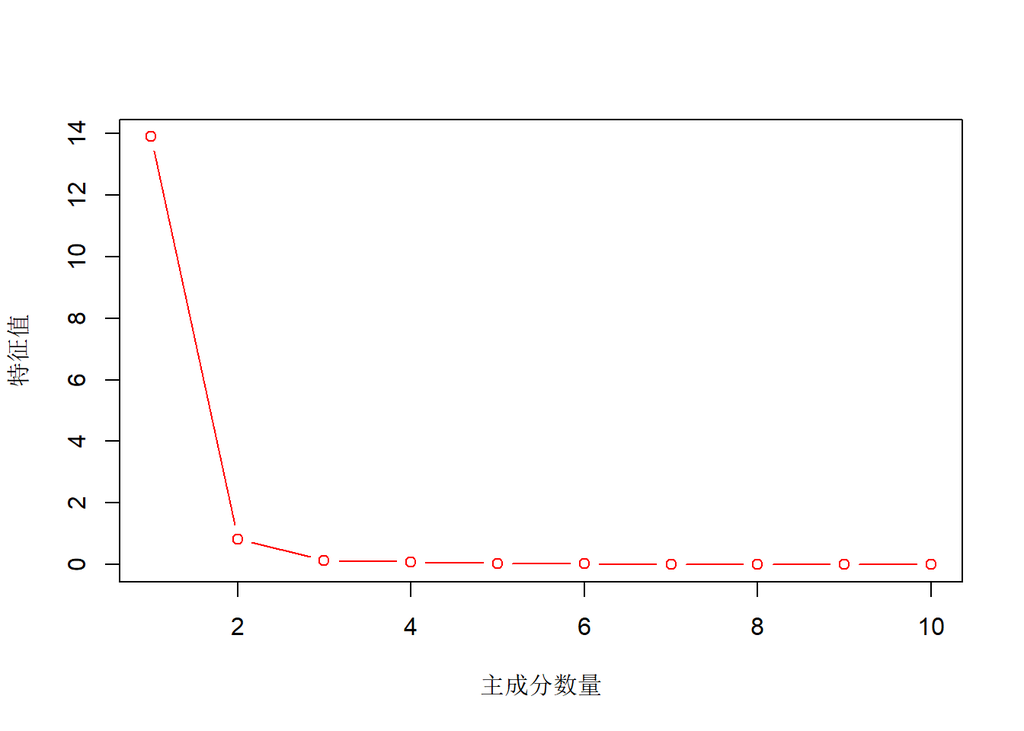

```r
start_time <- Sys.time()
pca <- principal(cor_df2[, -1], rotate = "none")

Sys.time() - start_time

plot(pca$values[1:10], type = "b",
     ylab = "特征值", xlab = "主成分数量", col = "red")
```

从上图可以看出，当主成分数量为3时，特征值趋于平稳。

```r
pca3 <- pca(cor_df2, nfactors = 3, rotate = "none")
```

```r
pca3.result <- pca3$loadings %>%
  as.vector() %>%
  matrix(ncol = 3) %>%
  as.data.frame()

colnames(pca3.result) <- paste0("PC", 1:3)
rownames(pca3.result) <- rownames(cor_df2)
head(pca3.result)
```

|  | PC1 | PC2 | PC3 |
| --- | --- | --- | --- |
| sales1 | 0.8740453 | -0.2127666 | 0.5496478 |
| sales2 | 0.9051599 | 0.4009066 | 0.4003806 |
| sales3 | 0.8938971 | 0.4509597 | 0.3496562 |
| sales4 | 0.4650606 | 1.0298997 | -0.1789368 |
| sales5 | 0.9657799 | 0.2726889 | -0.1355502 |
| sales6 | 0.9047659 | 0.2989285 | -0.5094366 |

层次聚类：

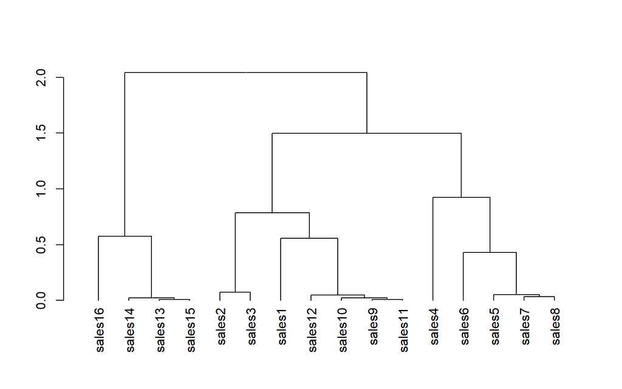

```r
hc <-
  pca3.result %>%
  dist() %>% # 计算distance矩阵,
  hclust(method = "complete") # 层次聚类

hc %>%
  as.dendrogram() %>%
  plot()
```

```r
myClusters <- hc %>%
  as.dendrogram() %>%
  cutree(3)

myClusters <- data.table(sales = names(myClusters),
                         tree = myClusters)
head(myClusters)
```

| sales | tree |
| --- | --- |
| sales1 | 1 |
| sales2 | 1 |
| sales3 | 1 |
| sales4 | 2 |
| sales5 | 2 |
| sales6 | 2 |

```r
myTrees <- myClusters %>% split(by = "tree")
str(myTrees)
```

```
## List of 3
##  $ 1:Classes 'data.table' and 'data.frame':  7 obs. of  2 variables:
##   ..$ sales: chr [1:7] "sales1" "sales2" "sales3" "sales9" ...
##   ..$ tree : int [1:7] 1 1 1 1 1 1 1
##   ..- attr(*, ".internal.selfref")=<externalptr>
##  $ 2:Classes 'data.table' and 'data.frame':  5 obs. of  2 variables:
##   ..$ sales: chr [1:5] "sales4" "sales5" "sales6" "sales7" ...
##   ..$ tree : int [1:5] 2 2 2 2 2
##   ..- attr(*, ".internal.selfref")=<externalptr>
##  $ 3:Classes 'data.table' and 'data.frame':  4 obs. of  2 variables:
##   ..$ sales: chr [1:4] "sales13" "sales14" "sales15" "sales16"
##   ..$ tree : int [1:4] 3 3 3 3
##   ..- attr(*, ".internal.selfref")=<externalptr>
```

# 7 可视化结果

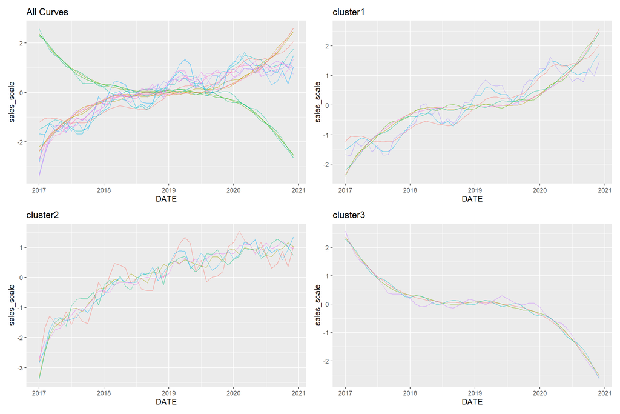

```r
p0 <- curves_DT2 %>%
  as.data.frame() %>%
  ggplot() +
  geom_line(aes(x = DATE, y = sales_scale, group = curves, color = curves),
            alpha = 0.5, show.legend = F) +
  scale_x_date() +
  ggtitle("All Curves")

p1 <- curves_DT2[curves %chin% myTrees[[1]]$sales] %>%
  as.data.frame() %>%
  ggplot() +
  geom_line(aes(x = DATE, y = sales_scale, group = curves, color = curves),
            alpha = 0.5, show.legend = F) +
  scale_x_date() +
  ggtitle("cluster1")

p2 <- curves_DT2[curves %chin% myTrees[[2]]$sales] %>%
  as.data.frame() %>%
  ggplot() +
  geom_line(aes(x = DATE, y = sales_scale, group = curves, color = curves),
            alpha = 0.5, show.legend = F) +
  scale_x_date() +
  ggtitle("cluster2")

p3 <- curves_DT2[curves %chin% myTrees[[3]]$sales] %>%
  as.data.frame() %>%
  ggplot() +
  geom_line(aes(x = DATE, y = sales_scale, group = curves, color = curves),
            alpha = 0.5, show.legend = F) +
  scale_x_date() +
  ggtitle("cluster3")


(p0 + p1)/(p2 + p3) # 拼图
```

看起来聚类效果还不错，只是cluster1中没有分离波动曲线与较平滑曲线。 如果要对这2类曲线进行分离，可以使用3次多项式拟合，然后根据残差绝对值和大小来区分，残差绝对值和大的属于波动剧烈的， 小的属于较平滑的曲线。

# 8 波动性分离

```r
curve_model <- function(df){
  lm(sales_scale ~ poly(DATE, 3), data = df)
}


fluctuate_df <- curves_DT2[curves %chin% myTrees[[1]]$sales] %>%
  as.data.frame() %>%
  group_nest(curves) %>% # 按曲线分组
  mutate(model = map(data, curve_model)) %>% # 拟合模型
  mutate(resids = map2(data, model, add_residuals)) %>%  # 计算残差
  mutate(resid_sum = map_dbl(resids, ~sum(abs(.x$resid)))) # 残差绝对值和

range(fluctuate_df$resid_sum)
head(fluctuate_df)
```

```
## [1]  0.3632877 12.0573163
```

| curves | data | model | resids | resid_sum |
| --- | --- | --- | --- | --- |
| sales1 |  |  |  | 5.779199 |
| sales10 |  |  |  | 2.128242 |
| sales11 |  |  |  | 2.952108 |
| sales12 |  |  |  | 2.385370 |
| sales2 |  |  |  | 11.008953 |
| sales3 |  |  |  | 12.057316 |

```r
Cluster1 <- fluctuate_df %>% filter(resid_sum < 4) %>% # 分离残差和小的曲线
  dplyr::select(curves, data) %>%
  unnest(data)

Cluster2 <- fluctuate_df %>% filter(resid_sum >= 4) %>% # 分离残差和大的曲线
  dplyr::select(curves, data) %>%
  unnest(data)
```

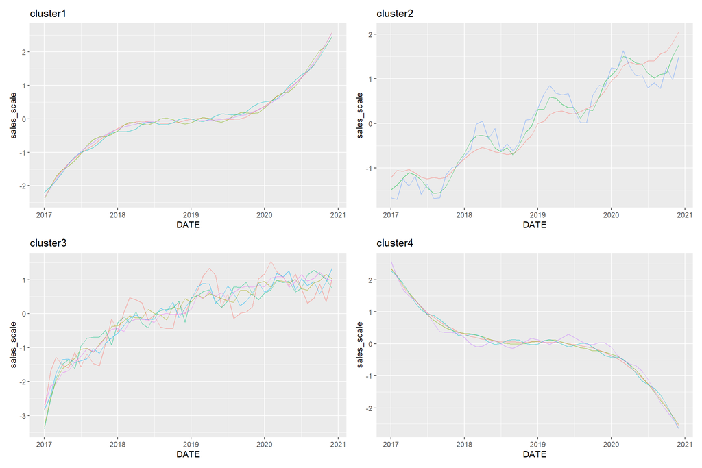

```r
p1 <- Cluster1 %>%
  ggplot() +
  geom_line(aes(x = DATE, y = sales_scale, group = curves, color = curves),
            alpha = 0.5, show.legend = F) +
  scale_x_date() +
  ggtitle("cluster1")

p2 <- Cluster2 %>%
  ggplot() +
  geom_line(aes(x = DATE, y = sales_scale, group = curves, color = curves),
            alpha = 0.5, show.legend = F) +
  scale_x_date() +
  ggtitle("cluster2")

p3 <- curves_DT2[curves %chin% myTrees[[2]]$sales] %>%
  as.data.frame() %>%
  ggplot() +
  geom_line(aes(x = DATE, y = sales_scale, group = curves, color = curves),
            alpha = 0.5, show.legend = F) +
  scale_x_date() +
  ggtitle("cluster3")

p4 <- curves_DT2[curves %chin% myTrees[[3]]$sales] %>%
  as.data.frame() %>%
  ggplot() +
  geom_line(aes(x = DATE, y = sales_scale, group = curves, color = curves),
            alpha = 0.5, show.legend = F) +
  scale_x_date() +
  ggtitle("cluster4")


(p1 + p2)/(p3 + p4) # 拼图
```

至此，曲线分离完毕，通过多种机器学习方法相结合，实现了不错的分离效果。 这里因为曲线数量有限，没有将上升趋势的和下降趋势的曲线进行分开处理，如果曲线数量非常大，最好分开处理， 否则曲线太多，并相互交叉，难以区分。